# Lab 8 Assignment

## Problem 1

*Use R to answer the following questions.*

In a certain large city, 34% of the adult population has a college degree. In a random sample of size 800,

1. What is the exact probability that between 250 and 290 adults have a college degree?

Hint: ( *Exact distribution:* B(800,.34).)

```r
pbinom(290,800,.34)-pbinom(250,800,.34)
```

```
## [1] 0.8622452
```

2. What is the approximate normal distribution of the fraction of adults in the sample with a college degree? *The fraction is a sample mean. What does the Central Limit Theorem say?* (Answer (i)-(iii) by hand)
- *for each person in the sample the question “Do you have a college degree?” is like a Bernoulli r.v., B(1,p).*

(i). *What is p?*

This is already given. p is 0.34

(ii). *what are the mean and standard deviation of a single result?*

.34

sqrt(.34*(1-.34)) = 0.4737

(iii). What is the distribution of the sample fraction, that is sample mean?

sqrt((.34*(1.-.34))/800) = 0.0167

Distribution: norm(0.34, 0.0167)

(iv). What is the probability, if the approximate normal distribution is used? (use R). Compare their result with the exact value.

```r
pnorm(q=290,mean=.34*800,sd=sqrt(.34*800*(1-.34)))-pnorm(q=250,mean=.34*800,sd=sqrt(.34*800*(1-.34)))
```

```
## [1] 0.8601364
```

The result is almost the same as the first problem.

- The sample fraction has an approximate normal distribution with mean $p$ and standard deviation $\sqrt{\frac{p(1-p)}{n}}$.
- The sample count (number of adults with college degree in the sample) has an approximate normal distribution with mean $np$ and standard deviation $\sqrt{np(1-p)}$.

# Problem 2

Repeat the Same likelihood example (Example 1) done for Poisson distribution in class for an exponential distribution.

1. Write a function to get the likelihood function for data from exponential distribution.

```r
mylikeli.exp = function(lambda,x){
   (lambda^length(x))*(exp(1)^(-lambda*(sum(x))))}
```

2. Generate a random sample of size 5 from an exponential distribution: Let’s say the variable named “X.2”.

```r
X.2 <- rexp(5)
```

3. Compute the likelihoods(using X.2) for a range of lambda(t) and plot them: Then find for which value the likelihood is maximized?

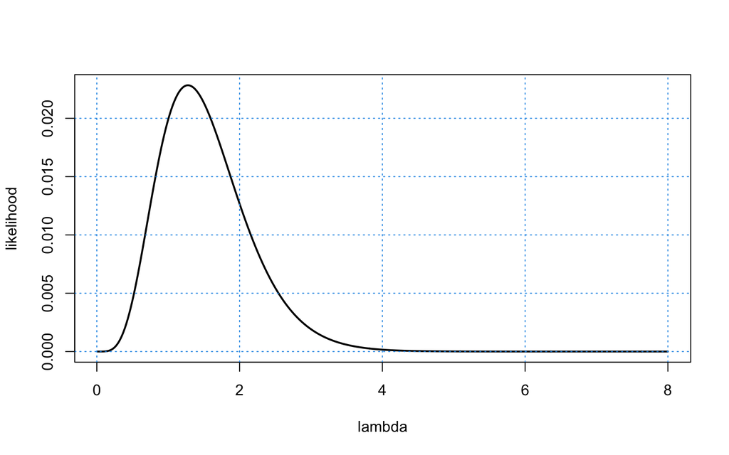

```r
t = seq(.01,8,by = .01) #range of lambda

y.1 <- sapply(t,function(t){mylikeli.exp(t,X.2)})

plot(t,y.1, xlab = 'lambda', ylab = 'likelihood',
        type = 'l', lwd = 2)
grid(col = 4)
```

```r
t[which.max(y.1)]
```

```
## [1] 1.28
```

4. Plot the same thing for log likelihood:

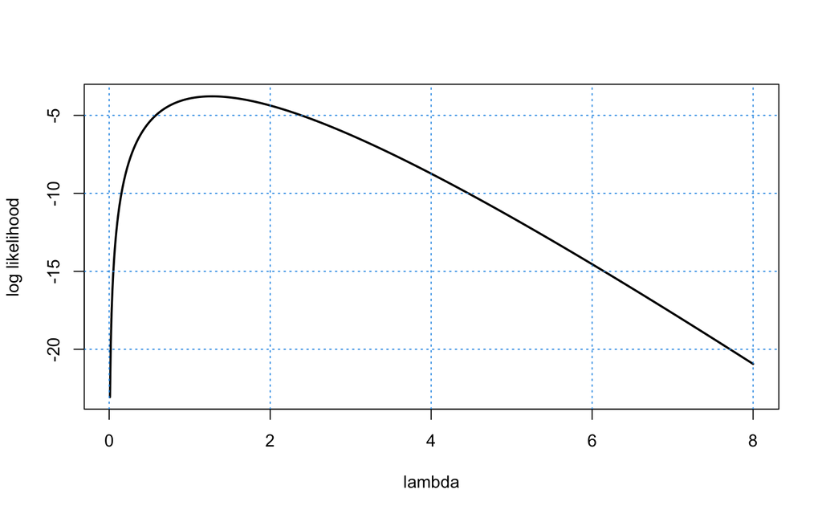

```r
t = seq(.01,8,by = .01) #range of lambda

y.1 <- sapply(t,function(t){log(mylikeli.exp(t,X.2))})

plot(t,y.1, xlab = 'lambda', ylab = 'log likelihood',
        type = 'l', lwd = 2)
grid(col = 4)
```

```r
t[which.max(y.1)]
```

```
## [1] 1.28
```

5. Repeat this 10 times
- 10 random samples with the same lambda
- plot each log-likelihood in the same plot
- what can you say about log likelihoods according to the plot? Does it have to do with the sample size we chose?

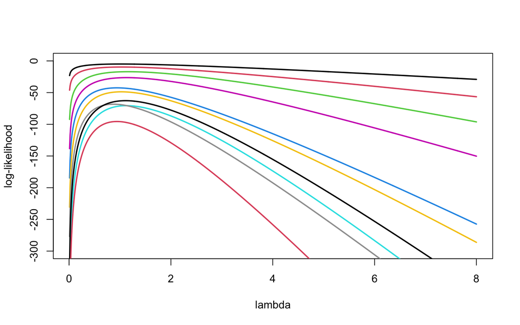

```r
mysize = c(5, 10, 20, 40, 80, 30, 50, 60, 70, 90)
likeli.1 <- matrix(NA, nrow = length(mysize), ncol = length(t))
for (j in 1:length(mysize)){
   mysample <- rexp(mysize[j])
   likeli.1[j,]  <- sapply(t,function(t){mylikeli.exp(t,mysample)})
}

plot(t,log(likeli.1[1,]), xlab = 'lambda', ylab = 'log-likelihood',
        type = 'l', lwd = 2, col = 1, ylim = c(-300,0))
for (j in 2:length(mysize)){
  lines(t,log(likeli.1[j,]), lwd = 2, col = j)
}
```

The parameter estimation is dependent on the observed values. Depending on the observations, I can estimate different MLE for lambda. With the given observations, I can make a good prediction on my parameters.

# Problem 3

Consider the probability distribution with density
$$f(x|\theta) = \begin{cases}
\theta x^{\theta - 1} \quad (0 \le x \le 1) \\
0 \quad \text{otherwise}
\end{cases}$$
where $\theta > 0$ is unknown.

Find a formula for the method-of-moments estimate for $\theta$.

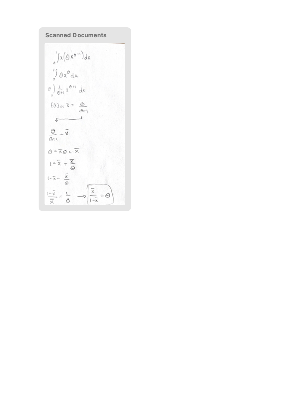

## Problem 4 (Bonus 5 points)

Exercise 6.4 #29 in Chihara/Hesterberg. *Note that these are essentially exponential distributions. There are three relative efficiencies to determine.*

$$var[\hat\theta_1] = \theta^2 \\
var[\hat\theta_2] = (1/4)(2\theta^2) = (1/2)\theta^2 \\
var[\hat\theta_3] = (1/9)(\theta^2+2^2\theta^2) = (5/9)\theta^2$$

Theta subscript 2 is the most efficient.

(sources: used the book chapter and answer key for guidance)